# Measuring Value in Reinsurance – edited for RBootcamp 2017

Gary G. Venter, Guy Carpenter Instrat (2017 partially adapted to .rmd by Dan Murphy)

For Venter’s original paper, see https://www.casact.org/pubs/forum/01sforum/01sf179.pdf.

## Abstract

Reinsurance produces value by producing stability. This can translate into higher earnings through reduced financing costs, improved access to markets, stronger product pricing and better employee job security. It can lead to a higher earnings multiple through reduction in the market price of possible bankruptcy and fewer misreadings of downwards earnings hits. Measuring these earnings and valuations effects is a developing science and for now we will only go as far as reviewing methods for measuring the stability that produces these benefits, and using these measures to compare alternative reinsurance programs.

Some of the conclusions are: standard deviation and variance can be misleading measures; using any measure with combined ratio can produce distortions in the analysis; the frequency of one reinsurance program producing a better result than another is not a very useful measure.

Measuring stability requires modeling. Making realistic models of insurers is a highly technical exercise with a number of possible pitfalls. Some of the technical details needed for modeling insurance financial risk are discussed.

## Introduction

When asked to do a cost/benefit analysis of their reinsurance purchases, insurers’ analysts sometimes do the following calculation. First they add up all the ceded premiums for the past several years. They call that the cost. Then they add up all the recoveries and ceding commissions received. That they identify as the benefit. Subtracting cost from benefit gives the net benefit [the **“Net Benefit of Reinsurance”** or **NBOR**]. After this calculation usually follows a lament that the net benefit has been negative. Sometimes one or two treaties have had a positive net benefit, but these are usually canceled or re-priced soon after. Occasionally some treaties return more than they cost over a long period of time, but pay losses several years after the premium has been received, so that premium plus loss investment income exceeds recoveries. The analyst decides that reinsurance has been a losing proposition for the company for some time.

A moment’s reflection, though, will reveal that this result was almost a foregone conclusion. Reinsurers are in business to make money, and some have succeeded at it. There are expenses involved. Thus over time total payouts by reinsurers have to be less than the premium they receive plus its related investment income. A given client can beat these odds in the short run, but probability eventually wins out – at least for the vast majority. And the exceptions usually are cedants with such poor results that they envy the rest.

So what’s wrong with the analysis? Is reinsurance just a bad deal that should be shut down as soon as possible, or are there some other benefits that this calculation misses? In the broadest terms, we would assert that the benefit of reinsurance is in gaining stability of results. This includes protection of surplus against erosion from adverse fluctuations, improvement in the predictability of earnings growth, and the provision of customers with assurance of recovery of their insured losses. There is a cost to gaining this benefit, but the cost is not simply ceded premiums. Premiums less recoveries (including expense recoveries) would be a better measure of the cost to the cedant for gaining stability. In fact this cost measure is what the naïve analyst got as the net benefit (**NBOR**).

So to sum up so far, the value of reinsurance is in the stability gained. The cost is the net of premiums and recoveries [**NBOR**]. For prospective analysis, the expected value of premiums less recoveries [*E(NBOR)*] would be the comparable cost measure. The next step is quantifying this cost/benefit trade-off.

## Quantifying Stability and Its Value

There are a few measures of stability that can be used – standard deviation and related quantities, percentiles or value at risk, and excess aggregates. Measures can be applied to surplus, earnings, or related accounts. Some companies prefer to look at more than one measure.

An additional step would be to translate the measure of stability into a measure of earnings gained through the increased stability. This could come in two directions:

1. reduction in capital costs for surplus not needed due to the reinsurance protection and from reduced costs of raising other capital because of improved debt ratings, etc.
2. other increases in earnings and firm value such as stock market valuation, risk elements in employee and management compensation, and improvements in access to customers and in the ability to get adequate premiums, perhaps related to improved claims paying ratings.

The former is perhaps more readily quantified, but the latter elements are also tangible financial benefits of a sound reinsurance program. The cost of the reinsurance program could well be offset by these effects on earnings and valuation. This is difficult to measure, however, and as it arises from the stability gained from the reinsurance program, we will be content here with just measures of that.

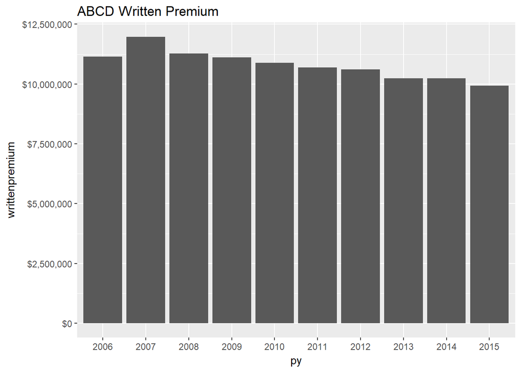

ABCD is considering two reinsurance programs:

- an excess-of-loss (XOL) program providing **750 x 250** cover for **$1.6M**
- an aggregate stop-loss (ASL) program of **30 x 40 (loss ratio)** for a premium of **$0.9M**.

Which is the a better option? Cost/benefit analysis addresses such issues.

Doing a cost/benefit analysis requires first establishing cost and benefit measures. A reasonable cost measure, as discussed above, is the net excess of ceded premiums over expected recoveries (**NBOR**). This can be estimated using a simulation study of financial results before and after reinsurance. Some of the technical issues of doing such a study are discussed later. **R** is being used to build a model of ABCD to simulate the financial results.

The table at the right

```r
NPNOR_Statistics
```

```
##               Statistic      BARE  NetOfXOL  NetOfASL
## 1                  Mean 5,218,541 4,423,024 5,272,689
## 2    Standard Deviation 1,413,958 1,024,867 673,162.6
## 3              Skewness    -2.071    -3.367     -7.51
## 4 Safety Level, Percent     99.0%     99.0%     99.0%
## 5   Safety Level, Value 7,451,590 5,968,695 6,641,253
```

from the simulation run shows some summary statistics for net premiums minus losses (gross less ceded) [**i.e., net premium net of recoveries** or **NPNOR**] prior to any expenses or investment income. The difference in the means is the relative net cost differential between two programs.

Most companies do not manage to a 25,000-year event, so a comparison is needed at more realistic probability levels. The graph below shows the simulated probability densities for the net premium less net losses [**net premium less net recoveries**, **NPNOR**].

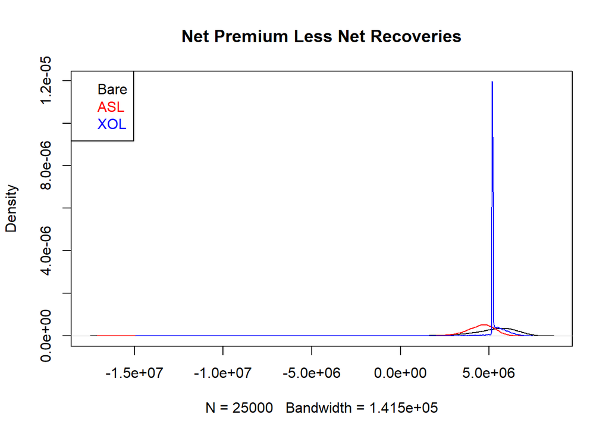

```r
plot(denB, main = "Net Premium Less Net Recoveries",
     ylim = c(0, max(denB$y, denX$y, denA$y)))
lines(denX, col = "red")
lines(denA, col = "blue")

#abline(v = mean(PNOR.DF$BARE))
#abline(v = mean(PNOR.DF$NetOfXOL), col = "red")
#abline(v = mean(PNOR.DF$NetOfASL), col = "blue")
legend("topleft",
       legend = c("Bare", "ASL", "XOL"),
       text.col = c("black", "red", "blue"))
```

[Figure 2]

It shows that the XOL program does produce a compression of results, but much of this compression comes by cutting off the profitability of the good years.

This is also a problem with using standard deviation as a measure of volatility: Standard deviation measures upward and downward deviations, and can be reduced by eliminating the favorable deviations. Measures that capture only unfavorable deviations are more useful, and will be discussed below [not in the 2017 RBootcamp].

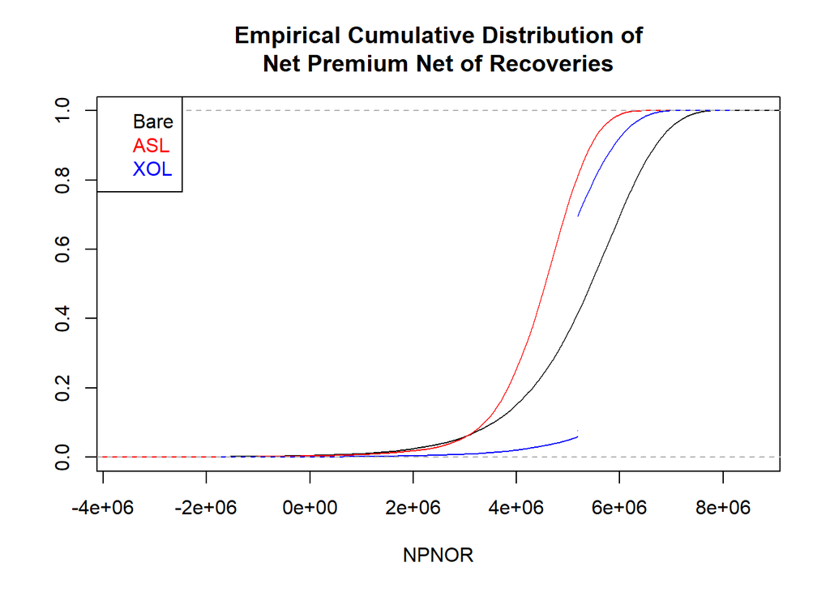

```r
plot(ecdf(PNOR.trimmed[[1]]),
     main = "Empirical Cumulative Distribution of\nNet Premium Net of Recoveries",
     xlab = "NPNOR", ylab = "")
lines(ecdf(PNOR.trimmed[[2]]), col = "red")
lines(ecdf(PNOR.trimmed[[3]]), col = "blue")
legend("topleft",
       legend = c("Bare", "ASL", "XOL"),
       text.col = c("black", "red", "blue"))
```

[Figure 3]

Also apparent in the graph is the concentration of events at the retention of the stop-loss program, and the similarity of the stop-loss and the gross or bare positions in good years.

```r
Table2
```

```
##         Row Probability        BARE    NetOfXOL     NetOfASL
## 14686     1     0.00004 -17100206.8 -16861664.4 -14913544.00
## 20867    62     0.00250  -2274576.4  -2793672.4    -87913.63
## 18638   125     0.00500   -466207.1   -709286.1   1720455.68
## 1455    188     0.00750    243109.3    314237.7   2429772.12
## 3207    250     0.01000    748268.6   1911150.8   2934931.41
## 8150    312     0.01250   1100846.5   1734081.1   3287509.33
## 5953    375     0.01500   1319988.9   1337094.0   3506651.69
## 10270   437     0.01750   1532440.1   2422546.0   3719102.92
## 18910   500     0.02000   1700171.7   1899369.8   3886834.50
## 10983  1000     0.04000   2518357.8   1937240.7   4705020.58
## 1926   1500     0.06000   2986997.0   3053778.0   5173659.80
## 19189  2000     0.08000   3281073.3   2886547.9   5183662.79
## 10698  2500     0.10000   3531056.3   3521912.7   5183662.79
## 14408  3000     0.12000   3738289.6   3933873.1   5183662.79
```

[output cut: 19 more lines]

[Table 2]

The above shows the general features of a cost/benefit comparison of alternative reinsurance programs. The cost is the expected income foregone by buying the program, and the benefit is the protection against adverse deviation. One way to specifically quantify the value of the protection is to look at the capital that would be absorbed by a loss at a selected adverse level – say the 1-in-100 level. In this example the gross loss at this level is $748,268.6 compared to $2,934,931 for the stop loss, which is a difference of $-2,186,663 in capital needed. If capital costs 15%, $-327,999.4 would be needed to raise this much, compared to the **$-0.1M** net cost of the reinsurance. The comparison is similar if pre-tax income is used as the basis rather than premium less losses. An even more dramatic savings would be shown if the capital requirement were set so that only 25% or some other limited part of surplus would be eroded by the worst year in 100.

## Other Comparisons

See [Gary’s paper](https://www.casact.org/pubs/forum/01sforum/01sf179.pdf).

## Conclusion

Cost/benefit analysis provides a useful methodology for insurers to quantify the value in their reinsurance transactions, and to compare among alternative structures. A good cost measure is the net decrease in under-writing earnings expected from the program (**“Net Benefit of Reinsurance”**).

## Acknowledgments

Thank you Brian for sending me the link to Gary’s *eForum* paper and thank you Gary for providing a pre-edition doc version … and saved me all this typing!